# 4-Classifiers

# k-NN

This notebook illustrates the code for Classifiers module. We will continue to use the Caret Package. The caret package (short for Classification And REgression Training) is a set of functions that attempt to streamline the process for creating predictive models. The package contains tools for:

- data splitting/partitioning
- pre-processing
- feature selection
- model tuning using resampling

Some code in this package comes from the following reference:

- https://www.dataminingbook.com/book/r-edition

Install packages if necessary. Uncomment before running.

```r
#install.packages("caret")
library(caret)
# install.packages("ISLR") # only install if needed
library(ISLR)
```

## Data Splitting

We will use the Carseats datasets.

```r
head(Carseats)
```

|  | Sales | CompPrice | Income | Advertising | Population | Price | ShelveLoc | Age | Education | Urban | US |
| --- | --- | --- | --- | --- | --- | --- | --- | --- | --- | --- | --- |
| 1 | 9.50 | 138 | 73 | 11 | 276 | 120 | Bad | 42 | 17 | Yes | Yes |
| 2 | 11.22 | 111 | 48 | 16 | 260 | 83 | Good | 65 | 10 | Yes | Yes |
| 3 | 10.06 | 113 | 35 | 10 | 269 | 80 | Medium | 59 | 12 | Yes | Yes |
| 4 | 7.40 | 117 | 100 | 4 | 466 | 97 | Medium | 55 | 14 | Yes | Yes |
| 5 | 4.15 | 141 | 64 | 3 | 340 | 128 | Bad | 38 | 13 | Yes | No |
| 6 | 10.81 | 124 | 113 | 13 | 501 | 72 | Bad | 78 | 16 | No | Yes |

```r
summary(Carseats)
```

```
     Sales          CompPrice       Income        Advertising       Population        Price        ShelveLoc
 Min.   : 0.000   Min.   : 77   Min.   : 21.00   Min.   : 0.000   Min.   : 10.0   Min.   : 24.0   Bad   : 96
 1st Qu.: 5.390   1st Qu.:115   1st Qu.: 42.75   1st Qu.: 0.000   1st Qu.:139.0   1st Qu.:100.0   Good  : 85
 Median : 7.490   Median :125   Median : 69.00   Median : 5.000   Median :272.0   Median :117.0   Medium:219
 Mean   : 7.496   Mean   :125   Mean   : 68.66   Mean   : 6.635   Mean   :264.8   Mean   :115.8
 3rd Qu.: 9.320   3rd Qu.:135   3rd Qu.: 91.00   3rd Qu.:12.000   3rd Qu.:398.5   3rd Qu.:131.0
 Max.   :16.270   Max.   :175   Max.   :120.00   Max.   :29.000   Max.   :509.0   Max.   :191.0
      Age          Education    Urban       US
 Min.   :25.00   Min.   :10.0   No :118   No :142
 1st Qu.:39.75   1st Qu.:12.0   Yes:282   Yes:258
 Median :54.50   Median :14.0
 Mean   :53.32   Mean   :13.9
 3rd Qu.:66.00   3rd Qu.:16.0
 Max.   :80.00   Max.   :18.0
```

- First, we create a dataset with only the required columns. We will use the dplyr package. Install it if necessary
- Then, we create an index for the training sample.
- We next create the training dataset
- We then use the reverse index of the training sample to create the validation set

```r
library(dplyr)
m_carseats <- select(Carseats,Sales,Age,Urban) # Select a subset of variables
set.seed(15)
Test_Index = createDataPartition(m_carseats$Sales,p=0.2, list=FALSE) # 20% reserved for Test
Test_Data = m_carseats[Test_Index,]
TraVal_Data = m_carseats[-Test_Index,] # Validation and Training data is rest
Train_Index = createDataPartition(TraVal_Data$Sales,p=0.75, list=FALSE) # 75% of remaining data as training
Train_Data = TraVal_Data[Train_Index,]
Validation_Data = TraVal_Data[-Train_Index,] # rest as validation
summary(Train_Data)
```

```
     Sales             Age        Urban
 Min.   : 0.000   Min.   :25.00   No : 72
 1st Qu.: 5.390   1st Qu.:39.00   Yes:168
 Median : 7.495   Median :54.00
 Mean   : 7.450   Mean   :52.83
 3rd Qu.: 9.322   3rd Qu.:65.25
 Max.   :16.270   Max.   :80.00
```

```r
summary(Validation_Data)
```

```
     Sales             Age        Urban
 Min.   : 2.930   Min.   :26.00   No :22
 1st Qu.: 5.370   1st Qu.:45.00   Yes:57
 Median : 7.490   Median :56.00
 Mean   : 7.629   Mean   :54.13
 3rd Qu.: 9.165   3rd Qu.:65.00
 Max.   :13.910   Max.   :80.00
```

```r
summary(Test_Data)
```

```
     Sales             Age     Urban
 Min.   : 2.070   Min.   :25   No :24
 1st Qu.: 5.530   1st Qu.:41   Yes:57
 Median : 7.320   Median :53
 Mean   : 7.504   Mean   :54
 3rd Qu.: 9.160   3rd Qu.:68
 Max.   :14.370   Max.   :80
```

## Plotting

Let us plot the data. I recommend you use ggplot, instead of the plot command.

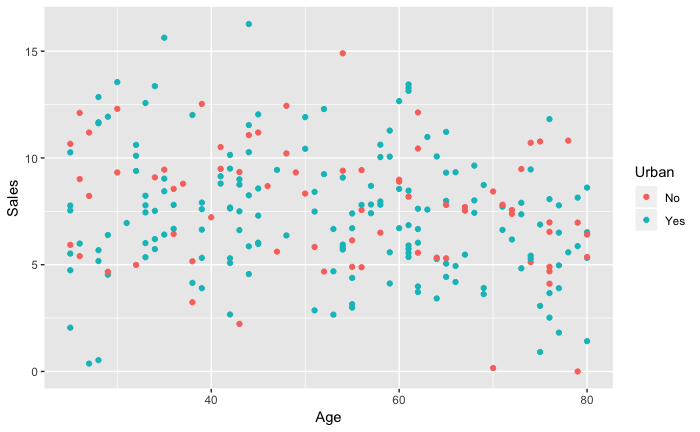

```r
library(ggplot2)
ggplot(Train_Data, aes(x=Age,y=Sales, color=Urban)) +
  geom_point()
```

## Normalization

Let us now normalize the data.

The preProcess ( ) function that is in the ‘caret’ package is a powerful method that has implemented a number of data processing and transformation methods.

The function implements min-max normalization using “range” as the method or z-score scaling when using “center” and “scale” as input method parameters.

```r
# Copy the original data
train.norm.df <- Train_Data
valid.norm.df <- Validation_Data
traval.norm.df <- TraVal_Data
# use preProcess() from the caret package to normalize Sales and Age.
norm.values <- preProcess(Train_Data[, 1:2], method=c("center", "scale"))
train.norm.df[, 1:2] <- predict(norm.values, Train_Data[, 1:2]) # Replace first two columns with normalized values
valid.norm.df[, 1:2] <- predict(norm.values, Validation_Data[, 1:2])
traval.norm.df[, 1:2] <- predict(norm.values, traval.norm.df[, 1:2])
test.norm.df <- predict(norm.values, Test_Data[, 1:2])
summary(train.norm.df)
```

```
     Sales               Age           Urban
 Min.   :-2.53267   Min.   :-1.68705   No : 72
 1st Qu.:-0.70032   1st Qu.:-0.83835   Yes:168
 Median : 0.01528   Median : 0.07098
 Mean   : 0.00000   Mean   : 0.00000
 3rd Qu.: 0.63655   3rd Qu.: 0.75297
 Max.   : 2.99838   Max.   : 1.64714
```

```r
var(train.norm.df[, 1:2])
```

```
           Sales        Age
Sales  1.0000000 -0.2033128
Age   -0.2033128  1.0000000
```

```r
summary(valid.norm.df)
```

```
     Sales               Age           Urban
 Min.   :-1.53660   Min.   :-1.62643   No :22
 1st Qu.:-0.70712   1st Qu.:-0.47462   Yes:57
 Median : 0.01358   Median : 0.19222
 Mean   : 0.06092   Mean   : 0.07865
 3rd Qu.: 0.58301   3rd Qu.: 0.73782
 Max.   : 2.19609   Max.   : 1.64714
```

```r
var(valid.norm.df[, 1:2])
```

```
           Sales        Age
Sales  0.8018890 -0.1695407
Age   -0.1695407  0.8905156
```

Notice that after normalization the mean and variance (standard deviation) of Sales and Age are 0 and 1, respectively. This is not true for the validation set as we use the data from the training set to normalize the values in the validation set.

## Modeling k-NN

Let us now apply knn. knn() is available in library FNN (provides a list of the nearest neighbors), and library class (allows a numerical output variable).

```r
# install.packages("FNN") Uncomment if need to install package
library(FNN)
nn <- knn(train = train.norm.df[, 1:2], test = test.norm.df,
          cl = train.norm.df[, 3], k = 3, prob=TRUE) # We use k = 3, and Urban is the Y
# print(nn) # uncomment for more output
row.names(Train_Data)[attr(nn, "nn.index")]
```

```
  [1] "43"  "189" "188" "198" "49"  "184" "176" "353" "140" "188" "315" "48"  "27"  "372" "228" "290" "184" "134"
 [19] "113" "276" "5"   "97"  "220" "169" "281" "387" "343" "123" "169" "113" "191" "298" "198" "49"  "364" "50"
 [37] "252" "46"  "165" "268" "375" "285" "97"  "214" "354" "101" "338" "278" "387" "97"  "292" "46"  "190" "79"
 [55] "159" "98"  "382" "25"  "214" "2"   "300" "292" "25"  "110" "318" "321" "316" "47"  "279" "280" "131" "228"
 [73] "184" "50"  "72"  "26"  "292" "181" "115" "188" "350" "57"  "338" "113" "63"  "196" "284" "264" "194" "396"
 [91] "113" "343" "100" "131" "228" "227" "118" "284" "17"  "56"  "263" "147" "71"  "274" "341" "329" "231" "315"
[109] "9"   "341" "188" "76"  "198" "298" "215" "11"  "332" "280" "243" "11"  "177" "350" "289" "71"  "390" "173"
[127] "215" "389" "322" "231" "71"  "136" "177" "122" "13"  "358" "322" "101" "139" "209" "299" "309" "226" "148"
[145] "37"  "222" "355" "265" "18"  "112" "199" "309" "372" "284" "332" "167" "353" "112" "250" "314" "308" "375"
[163] "18"  "389" "308" "298" "199" "374" "165" "233" "385" "308" "149" "66"  "187" "300" "244" "32"  "207" "373"
[181] "168" "268" "23"  "381" "3"   "335" "29"  "355" "376" "289" "335" "56"  "173" "135" "63"  "196" "179" "230"
[199] "13"  "327" "160" "262" "158" "132" "20"  "209" "291" "10"  "189" "286" "355" "20"  "226" "23"  "83"  "44"
[217] "242" "209" "10"  "1"   "322" "369" "372" "136" "139" "108" "138" "387" "176" "57"  "341" "252" "372" "108"
[235] "374" "230" "397" "194" "279" "103" "110" "333" "158"
```

Note the output provides class membership, and also a measure of distances from its nearest neighbors, in this case k=3.

But, how does one choose k?

## Hypertuning using Validation

To determine k, we use the performance on the validation set. Here, we will vary the value of k from 1 to 14

```r
# initialize a data frame with two columns: k, and accuracy.
library(caret)
accuracy.df <- data.frame(k = seq(1, 14, 1), accuracy = rep(0, 14))
# compute knn for different k on validation.
for(i in 1:14) {
  knn.pred <- knn(train.norm.df[, 1:2], valid.norm.df[, 1:2],
                  cl = train.norm.df[, 3], k = i)
  accuracy.df[i, 2] <- confusionMatrix(knn.pred, valid.norm.df[, 3])$overall[1]
}
accuracy.df
```

| k | accuracy |
| --- | --- |
| 1 | 0.5696203 |
| 2 | 0.4303797 |
| 3 | 0.5063291 |
| 4 | 0.4430380 |
| 5 | 0.5696203 |
| 6 | 0.4683544 |
| 7 | 0.5949367 |
| 8 | 0.5569620 |
| 9 | 0.7088608 |
| 10 | 0.6835443 |

[output cut: 4 more lines]

The value of k that provides the best performance is k = 9. We apply the results to the test set.

## Prediction

Before we predict for the test set, we should combine the Training and Validation set, normalize the data, and then do the prediction.

```r
norm.values <- preProcess(TraVal_Data[, 1:2], method=c("center", "scale")) # Use combined set to normalize
traval.norm.df[, 1:2] <- predict(norm.values, TraVal_Data[, 1:2])
test.norm.df[, 1:2] <- predict(norm.values, Test_Data[, 1:2])
summary(traval.norm.df)
```

```
     Sales                Age          Urban
 Min.   :-2.615380   Min.   :-1.7317   No : 94
 1st Qu.:-0.737884   1st Qu.:-0.8705   Yes:225
 Median :-0.001543   Median : 0.1138
 Mean   : 0.000000   Mean   : 0.0000
 3rd Qu.: 0.637085   3rd Qu.: 0.7289
 Max.   : 3.062476   Max.   : 1.6517
```

```r
summary(test.norm.df)
```

```
     Sales                Age
 Min.   :-1.892998   Min.   :-1.731688
 1st Qu.:-0.685537   1st Qu.:-0.747441
 Median :-0.060869   Median :-0.009256
 Mean   : 0.003283   Mean   : 0.052259
 3rd Qu.: 0.581249   3rd Qu.: 0.913475
 Max.   : 2.399419   Max.   : 1.651660
```

Now we predict for the test set.

```r
knn.pred.new <- knn(traval.norm.df[, 1:2], test.norm.df,
                    cl = traval.norm.df[, 3], k = 9)
row.names(TraVal_Data)[attr(nn, "nn.index")]
```

```
  [1] "35"  "143" "142" "149" "40"  "139" "131" "265" "104" "142" "230" "39"  "23"  "280" "172" "207" "139" "99"
 [19] "88"  "193" "5"   "71"  "167" "126" "198" "290" "259" "93"  "126" "88"  "145" "214" "149" "40"  "277" "42"
 [37] "184" "37"  "122" "190" "283" "202" "71"  "162" "268" "76"  "249" "194" "290" "71"  "209" "37"  "144" "61"
 [55] "115" "72"  "288" "21"  "162" "2"   "217" "209" "21"  "83"  "233" "235" "231" "38"  "196" "197" "97"  "172"
 [73] "139" "42"  "56"  "22"  "209" "136" "90"  "142" "263" "48"  "249" "88"  "51"  "148" "201" "188" "147" "295"
 [91] "88"  "259" "73"  "97"  "172" "170" "91"  "201" "12"  "47"  "187" "108" "55"  "191" "254" "241" "175" "230"
[109] "8"   "254" "142" "58"  "149" "214" "165" "10"  "243" "197" "180" "10"  "132" "263" "206" "55"  "292" "127"
[127] "165" "291" "237" "175" "55"  "101" "132" "92"  "11"  "276" "237" "76"  "103" "159" "215" "228" "169" "109"
[145] "31"  "168" "274" "189" "13"  "87"  "150" "228" "280" "201" "243" "124" "265" "87"  "183" "229" "227" "283"
[163] "13"  "291" "227" "214" "150" "282" "122" "176" "289" "227" "110" "53"  "141" "217" "181" "28"  "157" "281"
[181] "125" "190" "19"  "287" "3"   "245" "25"  "274" "284" "206" "245" "47"  "127" "100" "51"  "148" "134" "174"
[199] "11"  "240" "118" "186" "114" "98"  "14"  "159" "208" "9"   "143" "203" "274" "14"  "169" "19"  "65"  "36"
[217] "179" "159" "9"   "1"   "237" "278" "280" "101" "103" "81"  "102" "290" "131" "48"  "254" "184" "280" "81"
[235] "282" "174" "297" "147" "196" "78"  "83"  "244" "114"
```

# Creating Dummy Variables for Categorical Variables

One approach to calculate distances for categorical variables is to first convert them to numeric using dummy variables.

```r
levels(Carseats$US)
```

```
[1] "No"  "Yes"
```

```r
dummy_model <- dummyVars(~US,data=Carseats)
head(predict(dummy_model,Carseats))
```

```
  US.No US.Yes
1     0      1
2     0      1
3     0      1
4     0      1
5     1      0
6     0      1
```

# Hypertuning - kNN - Part 2

Earlier, we saw an example of hypertuning in determining the value of k. Small values, while sensitive to the data, may also model noise, while large values of k leads to smoother predictions, but are insensitive to local changes. We also saw an example above on how to pick k using the validation set results.

Here, we will use the Caret package that provides a wrapper for a large number of machine learning models (more than 200 models as of now). The train( ) function will automatically perform a grid search over a pre-defined set of hyperparameter values. It then select the best hyperparameter values, for us, k, using cross validations and train a model. This makes the process easier.

## Example - Hypertuning

```r
library(ISLR)
library(caret)
#Default dataset is a part of the ISLR package
# It captures credit card default status as well as balance, income, and student status
summary(Default)
```

```
 default    student       balance           income
 No :9667   No :7056   Min.   :   0.0   Min.   :  772
 Yes: 333   Yes:2944   1st Qu.: 481.7   1st Qu.:21340
                       Median : 823.6   Median :34553
                       Mean   : 835.4   Mean   :33517
                       3rd Qu.:1166.3   3rd Qu.:43808
                       Max.   :2654.3   Max.   :73554
```

### Normalization

```r
#let's normalize the data before modelling
norm_model<-preProcess(Default, method = c('range')) # We are using range here, but we can easily switch to c("center", "scale")
Default_normalized<-predict(norm_model,Default)
summary(Default_normalized)
```

```
 default    student       balance           income
 No :9667   No :7056   Min.   :0.0000   Min.   :0.0000
 Yes: 333   Yes:2944   1st Qu.:0.1815   1st Qu.:0.2826
                       Median :0.3103   Median :0.4641
                       Mean   :0.3147   Mean   :0.4499
                       3rd Qu.:0.4394   3rd Qu.:0.5913
                       Max.   :1.0000   Max.   :1.0000
```

```r
sd(Default_normalized$balance)
```

```
[1] 0.1822367
```

As we use the range for normalizing, the mean and variances are not 0, and 1 respectively.

### train

let’s train a k-NN model using the train() function from Caret

```r
# By setting the random seed, we can reproduce the results
set.seed(123)
model<-train(default~balance+income, data=Default_normalized, method="knn")
model
```

```
k-Nearest Neighbors

10000 samples
    2 predictor
    2 classes: 'No', 'Yes'

No pre-processing
Resampling: Bootstrapped (25 reps)
Summary of sample sizes: 10000, 10000, 10000, 10000, 10000, 10000, ...
Resampling results across tuning parameters:

  k  Accuracy   Kappa
  5  0.9642461  0.3497580
  7  0.9668646  0.3648712
  9  0.9691627  0.3841728

Accuracy was used to select the optimal model using the largest value.
The final value used for the model was k = 9.
```

### Customizing the search grid

Let us now customize the search space for k

```r
set.seed(123)
Serach_grid <- expand.grid(k=c(2,7,9,15))
model<-train(default~balance+income, data=Default_normalized,
             method="knn", tuneGrid=Serach_grid)
model
```

```
k-Nearest Neighbors

10000 samples
    2 predictor
    2 classes: 'No', 'Yes'

No pre-processing
Resampling: Bootstrapped (25 reps)
Summary of sample sizes: 10000, 10000, 10000, 10000, 10000, 10000, ...
Resampling results across tuning parameters:

  k   Accuracy   Kappa
   2  0.9562678  0.3005838
   7  0.9667990  0.3638844
   9  0.9690868  0.3829013
  15  0.9714312  0.3971779

Accuracy was used to select the optimal model using the largest value.
The final value used for the model was k = 15.
```

We have now restricted the search for the optimal k based on our search space. Finally, let us incorporate all aspects, preprocessing, train, and search in one function

### Final Function

```r
set.seed(123)
Serach_grid <- expand.grid(k=c(2,7,9,15))
model<-train(default~balance+income, data=Default,
             method="knn", tuneGrid=Serach_grid,
             preProcess='range')
model
```

```
k-Nearest Neighbors

10000 samples
    2 predictor
    2 classes: 'No', 'Yes'

Pre-processing: re-scaling to [0, 1] (2)
Resampling: Bootstrapped (25 reps)
Summary of sample sizes: 10000, 10000, 10000, 10000, 10000, 10000, ...
Resampling results across tuning parameters:

  k   Accuracy   Kappa
   2  0.9561052  0.3002330
   7  0.9669296  0.3675515
   9  0.9689893  0.3811722
  15  0.9713991  0.3964302

Accuracy was used to select the optimal model using the largest value.
The final value used for the model was k = 15.
```

# k-NN Class Package

```r
#install.packages("Class") #install first if needed
library(class)
library(caret)
library(ISLR)
summary(Default)
```

```
 default    student       balance           income
 No :9667   No :7056   Min.   :   0.0   Min.   :  772
 Yes: 333   Yes:2944   1st Qu.: 481.7   1st Qu.:21340
                       Median : 823.6   Median :34553
                       Mean   : 835.4   Mean   :33517
                       3rd Qu.:1166.3   3rd Qu.:43808
                       Max.   :2654.3   Max.   :73554
```

Let us now normalize the data

```r
#normalize the data first: build a model and apply
norm_model<-preProcess(Default, method = c('range'))
Default_normalized<-predict(norm_model,Default)
```

We now predict Default using income and balance

```r
Default_normalized<-Default_normalized[,-2]
# Use 80% of data for training and the rest for testing
Index_Train<-createDataPartition(Default_normalized$default, p=0.8, list=FALSE)
Train <-Default_normalized[Index_Train,]
Test  <-Default_normalized[-Index_Train,]
```

The Y variable is Default (first column), which is Yes, or No. Second and third columns are normalized “balance” and “income”

```r
Train_Predictors<-Train[,2:3]
Test_Predictors<-Test[,2:3]
Train_labels <-Train[,1]
Test_labels  <-Test[,1]
```

Train a knn model where k=4

```r
Predicted_Test_labels <-knn(Train_Predictors,
                           Test_Predictors,
                           cl=Train_labels,
               k=4 )
# Look at the 6 first values of predicted class (i.e., default status) of test set
head(Predicted_Test_labels)
```

```
[1] No No No No No No
Levels: No Yes
```

## Confusion Matrix

We can print out the confusion matrix, which is part of the CrossTable() function in the “gmodels” package

```r
install.packages("gmodels")
library("gmodels")
CrossTable(x=Test_labels,y=Predicted_Test_labels, prop.chisq = FALSE)
```

```
   Cell Contents
|-------------------------|
|                       N |
|           N / Row Total |
|           N / Col Total |
|         N / Table Total |
|-------------------------|


Total Observations in Table:  1999


             | Predicted_Test_labels
 Test_labels |        No |       Yes | Row Total |
-------------|-----------|-----------|-----------|
          No |      1906 |        27 |      1933 |
             |     0.986 |     0.014 |     0.967 |
             |     0.978 |     0.540 |           |
             |     0.953 |     0.014 |           |
-------------|-----------|-----------|-----------|
         Yes |        43 |        23 |        66 |
             |     0.652 |     0.348 |     0.033 |
             |     0.022 |     0.460 |           |
             |     0.022 |     0.012 |           |
-------------|-----------|-----------|-----------|
Column Total |      1949 |        50 |      1999 |
             |     0.975 |     0.025 |           |
-------------|-----------|-----------|-----------|
```

This matrix shows the following: If Yes is positive, then the misclassifications are 27 false positives, and 43 false negatives. We can identify several measures based on this table. For example

- Accuracy = Number correctly identified / Total = (23 + 1906) / 1999 = .965
- Recall is the true positive rate or sensitivity = 23 / 66 = .348
- Precision is the positive predictive value = 23 / (23 + 27) = 0.460
- Specificity, also called as the true negative rate = 1906 / 1933 = .986

In simple terms, high precision means that an algorithm returned substantially more relevant (positive) results than irrelevant (negative) ones, while high recall means that an algorithm returned most of the relevant (positive) results.

To find the proportion, look at the proportion across row. For example, false positive is the algorithm labelling a No as Yes, or in other words P (Yes | No) = 27 / 1933 = 0.014. Similarly, false negative is the algorithm labelling a Yes as a No, or P (No | Yes) = 43 / 66 = 0.652.

## Probability Output

Sometimes, it is preferred to have raw prediction probabilities rather than predicted class labels. knn () can additionally return probabilities if ‘prob’ argument is set to true. The probability is defined as the proportion of nearest neighbors that belongs to the majority class.For example, the probability will be 0.6 if 3 out of 5 nearest neighbors are from one class.

```r
Predicted_Test_labels <-knn(Train_Predictors,
                           Test_Predictors,
                           cl=Train_labels, k=100, prob=TRUE )
class_prob<-attr(Predicted_Test_labels, 'prob')
head(class_prob)
```

```
[1] 1 1 1 1 1 1
```